# DATA 624 Homework 5

Mario Pena

March 13, 2022

```r
library(fpp3)
library(tidyverse)
```

### Exercise 8.8.1

Consider the the number of pigs slaughtered in Victoria, available in the `aus_livestock` dataset.

**a.** Use the `ETS()` function to estimate the equivalent model for simple exponential smoothing. Find the optimal values of  
α and ℓ0, and generate forecasts for the next four months.

Even though I’ve seen these data in previous exercises, I decided to take a look at the variables again in the next few lines of code in order to filter the data with the required variables for this exercise:

```r
head(aus_livestock)
```

```
## # A tsibble: 6 x 4 [1M]
## # Key:       Animal, State [1]
##      Month Animal                     State                        Count
##      <mth> <fct>                      <fct>                        <dbl>
## 1 1976 Jul Bulls, bullocks and steers Australian Capital Territory  2300
## 2 1976 Aug Bulls, bullocks and steers Australian Capital Territory  2100
## 3 1976 Sep Bulls, bullocks and steers Australian Capital Territory  2100
## 4 1976 Oct Bulls, bullocks and steers Australian Capital Territory  1900
## 5 1976 Nov Bulls, bullocks and steers Australian Capital Territory  2100
## 6 1976 Dec Bulls, bullocks and steers Australian Capital Territory  1800
```

```r
aus_livestock %>%
  distinct(Animal)
```

```
## # A tibble: 7 x 1
##   Animal
##   <fct>
## 1 Bulls, bullocks and steers
## 2 Calves
## 3 Cattle (excl. calves)
## 4 Cows and heifers
## 5 Lambs
## 6 Pigs
## 7 Sheep
```

```r
aus_livestock %>%
  distinct(State)
```

```
## # A tibble: 8 x 1
##   State
##   <fct>
## 1 Australian Capital Territory
## 2 New South Wales
## 3 Northern Territory
## 4 Queensland
## 5 South Australia
## 6 Tasmania
## 7 Victoria
## 8 Western Australia
```

Below, we have an example of what the graph looks like for the number of pigs in Victoria before we apply any modeling techniques:

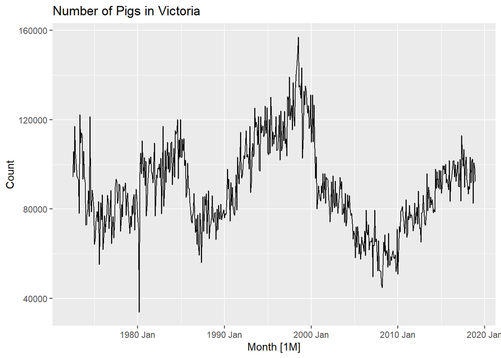

```r
aus_livestock %>%
  filter(State=="Victoria" & Animal=="Pigs") %>%
  autoplot(Count)+
  labs(y="Count", title="Number of Pigs in Victoria")
```

We assign the filtered data to variable “pigs”.

```r
#pigs data
pigs<-aus_livestock %>%
  filter(State=="Victoria" & Animal=="Pigs")
```

I borrowed some of the code from the textbook to build the model using the `ETS()` function. I have also acquired the optimal values of “alpha” and “l” below. The value of alpha is low, suggesting that more weight is given to observations from the past

```r
#model
fit <- pigs %>%
  model(ETS(Count ~ error("A") + trend("N") + season("N")))
fc <- fit %>%
  forecast(h = 4)

report(fit)
```

```
## Series: Count
## Model: ETS(A,N,N)
##   Smoothing parameters:
##     alpha = 0.3221247
##
##   Initial states:
##         l
##  100646.6
##
##   sigma^2:  87480760
##
##      AIC     AICc      BIC
## 13737.10 13737.14 13750.07
```

As we can observe below, the simple exponential smoothing function that we applied to model these data follows the original graph one step ahead.

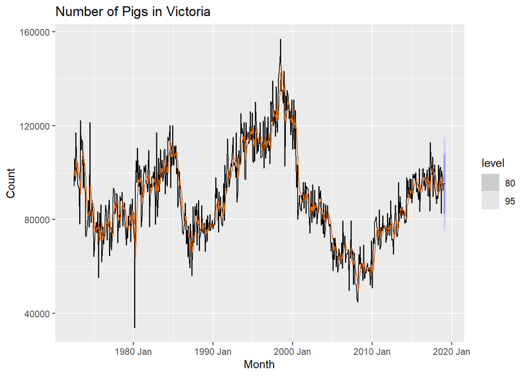

```r
fc %>%
  autoplot(pigs) +
  geom_line(aes(y = .fitted), col="#D55E00",
            data = augment(fit)) +
  labs(y="Count", title="Number of Pigs in Victoria") +
  guides(colour = "none")
```

**b.** Compute a 95% prediction interval for the first forecast using $\hat{y}\pm1.96s$ where s is the standard deviation of the residuals. Compare your interval with the interval produced by R.

We can observe below that the prediction interval for the first observation is [76854.79, 113518.3] generated by R.

```r
#prediction interval produced by R
pre_int = unpack_hilo(hilo(fc, 95) , "95%" )
pre_int
```

```
## # A tsibble: 4 x 8 [1M]
## # Key:       Animal, State, .model [1]
##   Animal State    .model    Month             Count  .mean `95%_lower` `95%_upper`
##   <fct>  <fct>    <chr>     <mth>            <dist>  <dbl>       <dbl>       <dbl>
## 1 Pigs   Victoria "ETS(~ 2019 Jan N(95187, 8.7e+07) 95187.      76855.     113518.
## 2 Pigs   Victoria "ETS(~ 2019 Feb N(95187, 9.7e+07) 95187.      75927.     114446.
## 3 Pigs   Victoria "ETS(~ 2019 Mar N(95187, 1.1e+08) 95187.      75042.     115331.
## 4 Pigs   Victoria "ETS(~ 2019 Apr N(95187, 1.1e+08) 95187.      74195.     116179.
```

Now we will use the mean from the first observation and the variance from our previous report to calculate the prediction interval by hand.

```r
#prediction interval by hand
m <- 95186.56

s <- sqrt(87480760)

low_y <- m - 1.96 * s
up_y <- m + 1.96 * s

paste(low_y, up_y)
```

```
## [1] "76854.4546212935 113518.665378707"
```

We can see that our results by hand and those of R are off by just a few decimals, thus they are practically identical.

### Exercise 8.8.5

Data set global_economy contains the annual Exports from many countries. Select one country to analyse.

**a.** Plot the Exports series and discuss the main features of the data.

I have picked Chile for this time series. We can see an upward trend with 3 big dips throughout the years. We can also observe that this trend starts to go down around the year 2008, but it is unclear whether this is another dip as we don’t have data past 2017. Thus we can’t see if it has gone back up.

```
## Plot variable not specified, automatically selected `.vars = Exports`
```

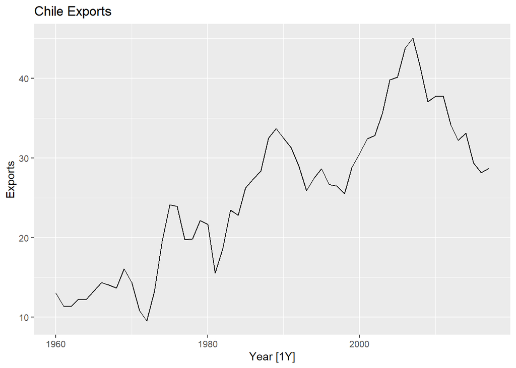

```r
#Chile exports
chile_exp <- global_economy %>%
  select("Year", Exports) %>%
  filter(Country == "Chile")
autoplot(chile_exp) +
  labs(y="Exports", title="Chile Exports")
```

**b.** Use an ETS(A,N,N) model to forecast the series, and plot the forecasts.

```r
#model
fit2 <- (chile_exp) %>%
  model(ETS(Exports ~ error("A") + trend("N") + season("N")))
fc2 <- fit2 %>%
  forecast(h = 4)

report(fit2)
```

```
## Series: Exports
## Model: ETS(A,N,N)
##   Smoothing parameters:
##     alpha = 0.9998997
##
##   Initial states:
##         l
##  13.06111
##
##   sigma^2:  6.7775
##
##      AIC     AICc      BIC
## 350.4596 350.9041 356.6410
```

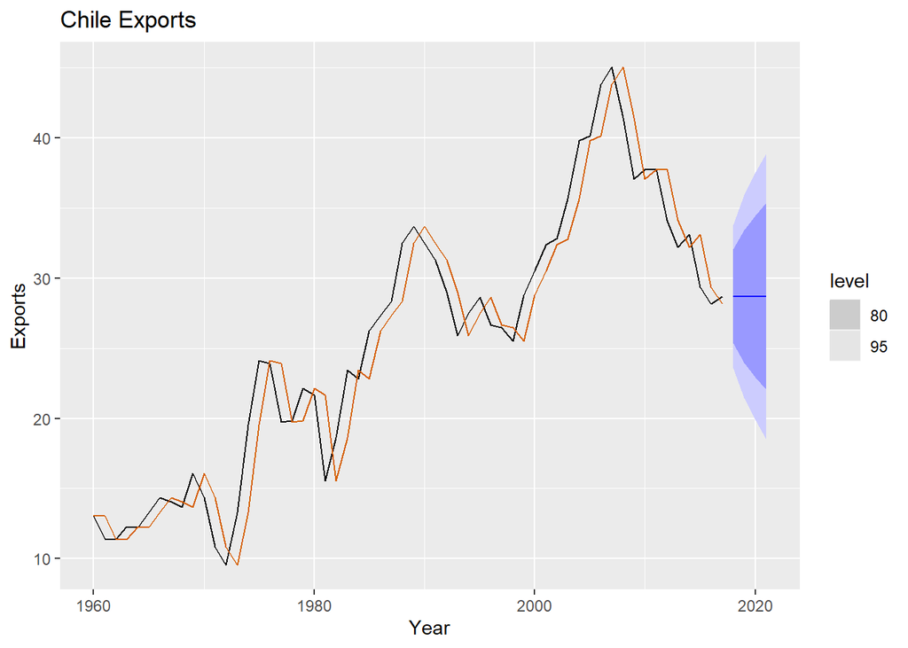

```r
fc2 %>%
  autoplot(chile_exp) +
  geom_line(aes(y = .fitted), col="#D55E00",
            data = augment(fit2))+
  labs(y="Exports", title="Chile Exports") +
  guides(colour = "none")
```

**c.** Compute the RMSE values for the training data.

```r
#metrics
accuracy(fit2)
```

```
## # A tibble: 1 x 11
##   Country .model           .type    ME  RMSE   MAE   MPE  MAPE  MASE RMSSE  ACF1
##   <fct>   <chr>            <chr> <dbl> <dbl> <dbl> <dbl> <dbl> <dbl> <dbl> <dbl>
## 1 Chile   "ETS(Exports ~ ~ Trai~ 0.270  2.56  1.99 0.598  8.80 0.983 0.991 0.272
```

**d.** Compare the results to those from an ETS(A,A,N) model. (Remember that the trended model is using one more parameter than the simpler model.) Discuss the merits of the two forecasting methods for this data set.

Using the `accuracy()` function below, we can see that the RMSE is practically identical to the one in the first model. In fact, most of the metrics have stayed about the same, except for ME, which has decreased in this new model as well as MPE, which seems to have inverted from positive to negative indicating a tendency to over-forecast.

```r
#model
fit3 <- (chile_exp) %>%
  model(ETS(Exports ~ error("A") + trend("A") + season("N")))
fc3 <- fit3 %>%
  forecast(h = 4)

accuracy(fit3)
```

```
## # A tibble: 1 x 11
##   Country .model        .type      ME  RMSE   MAE    MPE  MAPE  MASE RMSSE  ACF1
##   <fct>   <chr>         <chr>   <dbl> <dbl> <dbl>  <dbl> <dbl> <dbl> <dbl> <dbl>
## 1 Chile   "ETS(Exports~ Trai~ 0.00450  2.55  2.00 -0.550  9.06 0.989 0.988 0.263
```

**e.** Compare the forecasts from both methods. Which do you think is best?

The new model is showing a forecast with an upward trend as opposed to the first model showing a forecast of a straight line from the last observation in the data. Based on RMSE I would say that the second model is slightly better. Moreover, the additional parameter in the second model may be helping with forecasting the trend-cycle component.

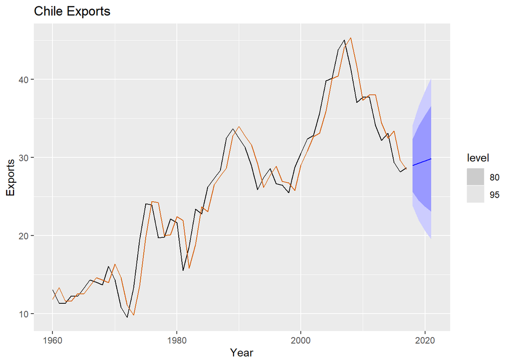

```r
fc3 %>%
  autoplot(chile_exp) +
  geom_line(aes(y = .fitted), col="#D55E00",
            data = augment(fit3))+
  labs(y="Exports", title="Chile Exports") +
  guides(colour = "none")
```

**f.** Calculate a 95% prediction interval for the first forecast for each model, using the RMSE values and assuming normal errors. Compare your intervals with those produced using R.

The 95% prediction intervals produced by R for the first forecast for each of the two models are as follow:

```r
#first and second model intervals produced by R
pre_int2 = unpack_hilo(hilo(fc2, 95) , "95%" )
pre_int2
```

```
## # A tsibble: 4 x 7 [1Y]
## # Key:       Country, .model [1]
##   Country .model                   Year    Exports .mean `95%_lower` `95%_upper`
##   <fct>   <chr>                   <dbl>     <dist> <dbl>       <dbl>       <dbl>
## 1 Chile   "ETS(Exports ~ error(\~  2018 N(29, 6.8)  28.7        23.6        33.8
## 2 Chile   "ETS(Exports ~ error(\~  2019  N(29, 14)  28.7        21.5        35.9
## 3 Chile   "ETS(Exports ~ error(\~  2020  N(29, 20)  28.7        19.9        37.5
## 4 Chile   "ETS(Exports ~ error(\~  2021  N(29, 27)  28.7        18.5        38.9
```

```r
pre_int3 = unpack_hilo(hilo(fc3, 95) , "95%" )
pre_int3
```

```
## # A tsibble: 4 x 7 [1Y]
## # Key:       Country, .model [1]
##   Country .model                    Year   Exports .mean `95%_lower` `95%_upper`
##   <fct>   <chr>                    <dbl>    <dist> <dbl>       <dbl>       <dbl>
## 1 Chile   "ETS(Exports ~ error(\"~  2018  N(29, 7)  29.0        23.8        34.2
## 2 Chile   "ETS(Exports ~ error(\"~  2019 N(29, 14)  29.3        22.0        36.6
## 3 Chile   "ETS(Exports ~ error(\"~  2020 N(30, 21)  29.6        20.6        38.5
## 4 Chile   "ETS(Exports ~ error(\"~  2021 N(30, 28)  29.9        19.5        40.2
```

The 95% prediction intervals done manually for the first forecast for each of the two models using RMSE values are as follow:

```r
#first model interval
m2 <- 28.7

rmse2 <- 2.56

low_y2 <- m2 - 1.96 * rmse2
up_y2 <- m2 + 1.96 * rmse2

paste(low_y2, up_y2)
```

```
## [1] "23.6824 33.7176"
```

```r
#second model interval
m3 <- 28.99

rmse3 <- 2.55

low_y3 <- m3 - 1.96 * rmse3
up_y3 <- m3 + 1.96 * rmse3

paste(low_y3, up_y3)
```

```
## [1] "23.992 33.988"
```

The prediction intervals produced by R and those produced by hand are very close to each other.

### Exercise 8.8.6

Forecast the Chinese GDP from the `global_economy` data set using an ETS model. Experiment with the various options in the `ETS()` function to see how much the forecasts change with damped trend, or with a Box-Cox transformation. Try to develop an intuition of what each is doing to the forecasts.

```r
head(global_economy)
```

```
## # A tsibble: 6 x 9 [1Y]
## # Key:       Country [1]
##   Country     Code   Year         GDP Growth   CPI Imports Exports Population
##   <fct>       <fct> <dbl>       <dbl>  <dbl> <dbl>   <dbl>   <dbl>      <dbl>
## 1 Afghanistan AFG    1960  537777811.     NA    NA    7.02    4.13    8996351
## 2 Afghanistan AFG    1961  548888896.     NA    NA    8.10    4.45    9166764
## 3 Afghanistan AFG    1962  546666678.     NA    NA    9.35    4.88    9345868
## 4 Afghanistan AFG    1963  751111191.     NA    NA   16.9     9.17    9533954
## 5 Afghanistan AFG    1964  800000044.     NA    NA   18.1     8.89    9731361
## 6 Afghanistan AFG    1965 1006666638.     NA    NA   21.4    11.3     9938414
```

```
## Plot variable not specified, automatically selected `.vars = GDP`
```

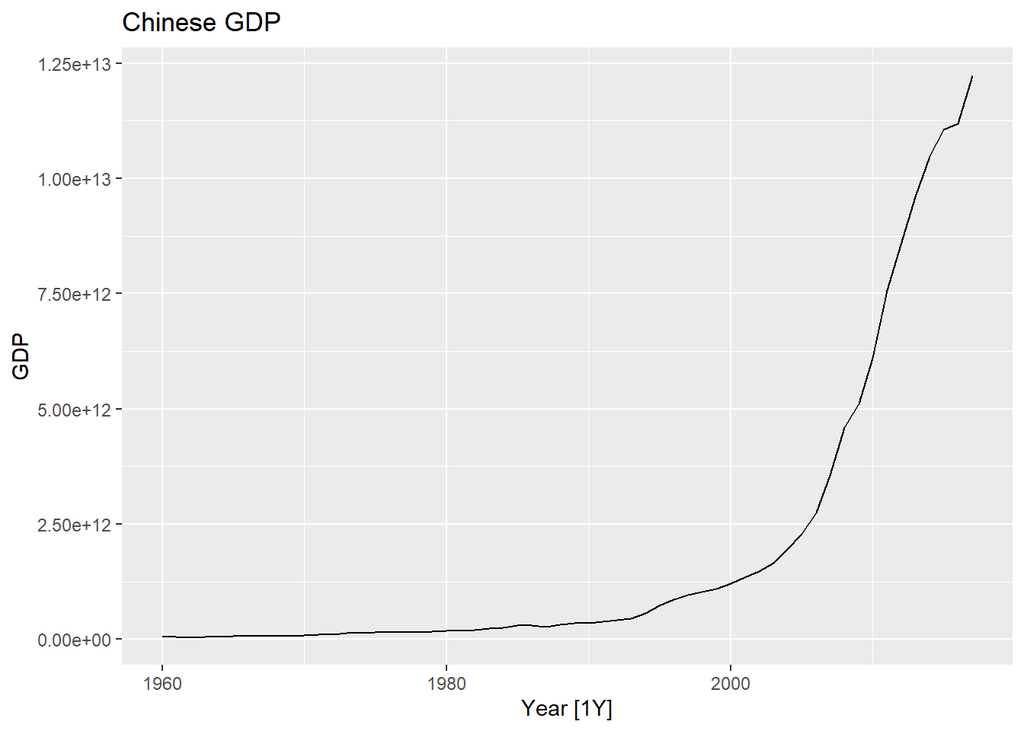

```r
#chinese gdp
china_gdp <- global_economy %>%
  select("Year", GDP) %>%
  filter(Country=="China")
autoplot(china_gdp) +
  labs(y="GDP", title="Chinese GDP")
```

Let’s take a look at the components of these data:

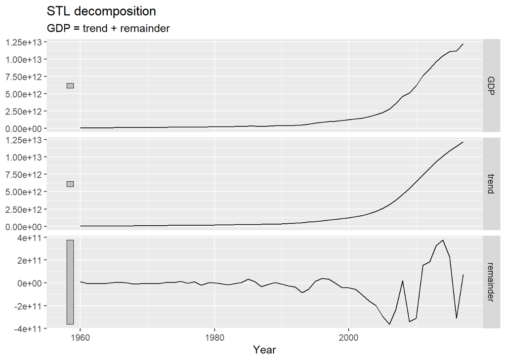

```r
#STL decomposition
dcmp <- china_gdp %>%
  model(stl = STL(GDP))

components(dcmp) %>% autoplot()
```

Now we will take a look at some ETS() models:

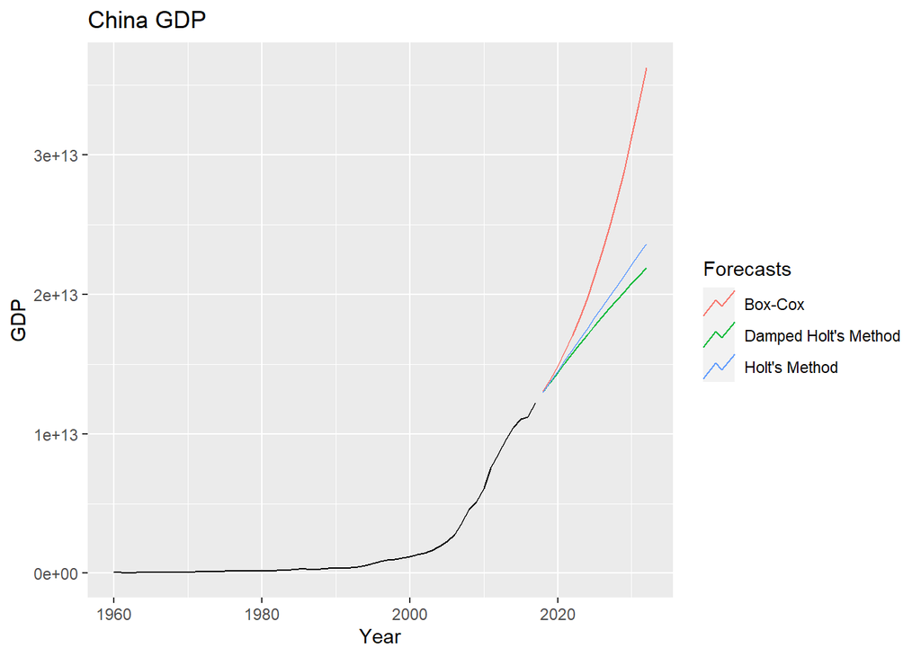

```r
#lambda for boxcox
lambda <- china_gdp %>%
  features(GDP, features = guerrero) %>%
  pull(lambda_guerrero)

# models
china_gdp %>%
  model(
    "Holt's Method" = ETS(GDP ~ error('A') + trend('A') + season('N')),
    "Damped Holt's Method" = ETS(GDP ~ error('A') + trend('Ad') + season('N')),
    "Box-Cox" = ETS(box_cox(GDP, lambda) ~ error('A') + trend('Ad') + season('N'))
  ) %>%
  forecast(h = 15) %>%
  autoplot(china_gdp, level = NULL) +
  labs(title = "China GDP",
       y = "GDP") +
  guides(colour = guide_legend(title = "Forecasts"))
```

We can observe above that Holt’s method seems to over-forecast as it has a constant upward trend. On the other hand, the damped method seems to slowly bring the upward trend to a straight horizontal line. Interestingly, the Box-Cox combination with the damped method seems to be over-forecasting above both the previous methods. Perhaps the lambda found by the `guerrero` function might have squared our original data, hence the exponential growth.